# Exemple Pràctica Estadística

José Luis Lisani

# 1 Dades Airbnb, ciutat: Austin (Texas, USA)

Font: http://insideairbnb.com/get-the-data.html

```r
library(knitr)

setwd("~/Dropbox/STATIC/Docencia/EstadisticaGINF/curs2019-2020/practicaOrdinador")
rawdata=read.csv("listingsAustin.csv", stringsAsFactors=FALSE)
```

```r
#str(rawdata)
```

```r
#head(rawdata)
```

Extracció de dades relevants a partir de les dades brutes. Per als preus, utilitzar el valor numèric (sense el símbol de $ of €).

```r
data=data.frame(rawdata$neighbourhood, rawdata$property_type, rawdata$accommodates, rawdata$beds, rawdata$bedrooms, rawdata$bathrooms, rawdata$price, rawdata$security_deposit, rawdata$minimum_nights, rawdata$review_scores_rating, rawdata$number_of_reviews, rawdata$host_response_time)

data$rawdata.price = as.numeric(gsub("\\$", "", data$rawdata.price))
data$rawdata.security_deposit = as.numeric(gsub("\\$", "", data$rawdata.security_deposit))
#data$rawdata.price = as.numeric(gsub(",", "", gsub("\\$", "", data$rawdata.price)))
#data$rawdata.security_deposit = as.numeric(gsub(",", "", gsub("\\$", "", data$rawdata.security_deposit)))

str(data)
```

```
## 'data.frame':    11520 obs. of  12 variables:
##  $ rawdata.neighbourhood       : Factor w/ 79 levels "","Allendale",..: 23 23 23 64 66 79 24 1 66 72 ...
##  $ rawdata.property_type       : Factor w/ 35 levels "Aparthotel","Apartment",..: 22 22 19 22 19 19 18 22 22 22 ...
##  $ rawdata.accommodates        : int  4 2 3 2 2 3 2 6 5 4 ...
##  $ rawdata.beds                : int  2 2 2 1 1 2 1 3 2 4 ...
##  $ rawdata.bedrooms            : int  2 1 1 1 0 1 1 3 2 2 ...
##  $ rawdata.bathrooms           : num  2 1 1 1 1 1 1 2 1 1 ...
##  $ rawdata.price               : num  225 100 95 40 99 129 40 300 550 220 ...
##  $ rawdata.security_deposit    : num  500 500 100 NA NA 200 0 200 0 300 ...
##  $ rawdata.minimum_nights      : int  30 30 2 1 4 3 3 1 1 30 ...
##  $ rawdata.review_scores_rating: int  93 91 97 98 99 99 92 99 98 97 ...
##  $ rawdata.number_of_reviews   : int  24 9 522 257 109 224 46 28 91 35 ...
##  $ rawdata.host_response_time  : Factor w/ 6 levels "","a few days or more",..: 5 5 5 3 6 6 4 6 6 5 ...
```

```r
head(data)
```

```
##   rawdata.neighbourhood rawdata.property_type rawdata.accommodates
## 1         East Downtown                 House                    4
## 2         East Downtown                 House                    2
## 3         East Downtown            Guesthouse                    3
## 4     SW Williamson Co.                 House                    2
## 5        Travis Heights            Guesthouse                    2
## 6                Zilker            Guesthouse                    3
##   rawdata.beds rawdata.bedrooms rawdata.bathrooms rawdata.price
## 1            2                2                 2           225
## 2            2                1                 1           100
## 3            2                1                 1            95
## 4            1                1                 1            40
## 5            1                0                 1            99
## 6            2                1                 1           129
##   rawdata.security_deposit rawdata.minimum_nights
```

[output cut: 20 more lines]

Renombrar columnes: “Barri”, “Tipus”, “Capacitat”, “Nombre llits”, “Nombre habitacions”, “Nombre de banys”, “Preu”, “Dipòsit”, “Mínim nombre de nits”, “Valoració mitjana”, “Nombre de valoracions”, “Resposta propietari(a)”

```r
names(data)=c("Barri", "Tipus", "Capacitat", "Nombre llits", "Nombre habitacions", "Nombre de banys", "Preu", "Dipòsit", "Mínim nombre de nits", "Valoració mitjana", "Nombre de valoracions", "Resposta propietari(a)")

head(data)
```

```
##               Barri      Tipus Capacitat Nombre llits Nombre habitacions
## 1     East Downtown      House         4            2                  2
## 2     East Downtown      House         2            2                  1
## 3     East Downtown Guesthouse         3            2                  1
## 4 SW Williamson Co.      House         2            1                  1
## 5    Travis Heights Guesthouse         2            1                  0
## 6            Zilker Guesthouse         3            2                  1
##   Nombre de banys Preu Dipòsit Mínim nombre de nits Valoració mitjana
## 1               2  225     500                   30                93
## 2               1  100     500                   30                91
## 3               1   95     100                    2                97
## 4               1   40      NA                    1                98
## 5               1   99      NA                    4                99
## 6               1  129     200                    3                99
##   Nombre de valoracions Resposta propietari(a)
## 1                    24     within a few hours
## 2                     9     within a few hours
## 3                   522     within a few hours
## 4                   257                    N/A
## 5                   109         within an hour
## 6                   224         within an hour
```

Estadístics:

- per a les variables numèriques: quantitat valors no vàlids, mínim, màxim, mitjana, variància, quartils, mediana
- per a les variables no numèriques: taules amb quantitat de cada tipus de valors

```r
summary(data)
```

```
##                  Barri              Tipus        Capacitat
##  East Downtown      :1062   House      :5069   Min.   : 1.000
##                     : 851   Apartment  :3051   1st Qu.: 2.000
##  Downtown           : 730   Condominium:1057   Median : 4.000
##  Travis Heights     : 451   Guesthouse : 522   Mean   : 4.706
##  University of Texas: 437   Townhouse  : 418   3rd Qu.: 6.000
##  East Riverside     : 360   Bungalow   : 298   Max.   :33.000
##  (Other)            :7629   (Other)    :1105
##   Nombre llits     Nombre habitacions Nombre de banys       Preu
##  Min.   :  0.000   Min.   : 0.000     Min.   : 0.000   Min.   :  0.0
##  1st Qu.:  1.000   1st Qu.: 1.000     1st Qu.: 1.000   1st Qu.: 79.0
##  Median :  2.000   Median : 1.000     Median : 1.000   Median :132.0
##  Mean   :  2.537   Mean   : 1.787     Mean   : 1.545   Mean   :206.7
##  3rd Qu.:  3.000   3rd Qu.: 2.000     3rd Qu.: 2.000   3rd Qu.:250.0
##  Max.   :132.000   Max.   :23.000     Max.   :17.000   Max.   :999.0
##  NA's   :40        NA's   :5          NA's   :14       NA's   :740
##     Dipòsit      Mínim nombre de nits Valoració mitjana
##  Min.   :  0.0   Min.   :  1.000      Min.   : 20.00
##  1st Qu.:  0.0   1st Qu.:  1.000      1st Qu.: 95.00
##  Median :100.0   Median :  2.000      Median : 98.00
##  Mean   :169.7   Mean   :  5.314      Mean   : 96.04
##  3rd Qu.:250.0   3rd Qu.:  2.000      3rd Qu.:100.00
##  Max.   :999.0   Max.   :500.000      Max.   :100.00
##  NA's   :3687                         NA's   :2581
##  Nombre de valoracions        Resposta propietari(a)
##  Min.   :  0.00                          :   2
##  1st Qu.:  1.00        a few days or more: 114
##  Median :  7.00        N/A               :3596
##  Mean   : 31.21        within a day      : 540
##  3rd Qu.: 32.00        within a few hours: 937
##  Max.   :932.00        within an hour    :6331
##
```

```r
# variables numèriques
varnum=c("Capacitat", "Nombre llits", "Nombre habitacions", "Nombre de banys", "Preu", "Dipòsit", "Mínim nombre de nits", "Valoració mitjana", "Nombre de valoracions")

# data frame només amb variables numèriques
datanum=data[varnum]
```

```r
# variable no numèriques
varnonum=c("Barri", "Tipus", "Resposta propietari(a)")

# data frame només amb variables numèriques
datanonum=data[varnonum]
```

```r
estadistics_varnum=function(x)
{
  N=as.numeric(table(!is.na(x))["TRUE"])
  NAs=length(x)-N

  return(c(N=N,NAs=NAs,mitjana=mean(x, na.rm=TRUE),variancia=var(x, na.rm=TRUE),
           des_tip=sd(x, na.rm=TRUE),
           Q1=quantile(x,0.25, na.rm=TRUE),Q3=quantile(x,0.75, na.rm=TRUE),mediana=median(x, na.rm=TRUE),
           Max=max(x, na.rm=TRUE),Min=min(x, na.rm=TRUE)))
}

aux=apply(datanum,2,estadistics_varnum)

knitr::kable(t(round(aux,2)),digits = 2,aling="c",caption="Estadístics bàsics per a les variables numèriques")
```

Estadístics bàsics per a les variables numèriques

|  | N | NAs | mitjana | variancia | des_tip | Q1.25% | Q3.75% | mediana | Max | Min |
| --- | --- | --- | --- | --- | --- | --- | --- | --- | --- | --- |
| Capacitat | 11520 | 0 | 4.71 | 10.49 | 3.24 | 2 | 6 | 4 | 33 | 1 |
| Nombre llits | 11480 | 40 | 2.54 | 7.35 | 2.71 | 1 | 3 | 2 | 132 | 0 |
| Nombre habitacions | 11515 | 5 | 1.79 | 1.61 | 1.27 | 1 | 2 | 1 | 23 | 0 |
| Nombre de banys | 11506 | 14 | 1.55 | 0.76 | 0.87 | 1 | 2 | 1 | 17 | 0 |
| Preu | 10780 | 740 | 206.74 | 39277.57 | 198.19 | 79 | 250 | 132 | 999 | 0 |
| Dipòsit | 7833 | 3687 | 169.67 | 38816.04 | 197.02 | 0 | 250 | 100 | 999 | 0 |
| Mínim nombre de nits | 11520 | 0 | 5.31 | 297.34 | 17.24 | 1 | 2 | 2 | 500 | 1 |
| Valoració mitjana | 8939 | 2581 | 96.04 | 48.73 | 6.98 | 95 | 100 | 98 | 100 | 20 |
| Nombre de valoracions | 11520 | 0 | 31.21 | 3845.80 | 62.01 | 1 | 32 | 7 | 932 | 0 |

```r
#no funciona
# for(i in 1:ncol(datanonum)) {
#   table(datanonum[i])
# }

table(datanonum[1])
```

```
##
##                                             Allendale
##                        851                        116
##              Anderson Mill               Angus Valley
##                         26                         25
## Balcones Civic Association              Balcony Woods
##                         52                         57
##               Barton Creek               Barton Hills
##                        101                        287
##              Bouldin Creek                  Brentwood
##                        333                        125
##               Bryker Woods                 Bull Creek
##                         31                         26
##                Canyon Mesa               Cat Mountian
##                          6                         10
##               Cherry Creek                   Circle C
##                        233                         40
##                Clarksville                Copperfield
##                        118                         60
##                  Crestview                     Dawson
##                         65                        103
##                   Downtown              East Congress
##                        730                         76
##              East Downtown             East Riverside
##                       1062                        360
##                    Galindo                    Gateway
##                        107                         23
##             Georgian Acres                    Govalle
##                         40                        171
##                 Gracywoods                    Hancock
##                         80                        161
##                   Highland                      Holly
##                         82                        153
##                  Hyde Park          Lamplight Village
##                        151                         45
##                Long Canyon                   McKinney
##                        100                        207
##                  Mesa Park                    Milwood
##                         12                         44
##                  MLK & 183                 Montopolis
```

[output cut: 26 more lines]

```
##                        120                        451
##           University Hills        University of Texas
##                         38                        437
##          Upper Boggy Creek               Walnut Creek
##                        201                          7
##                West Austin                West Campus
##                         82                        192
##              West Congress                   Westgate
##                        162                         60
##             Westlake Hills              Windsor Hills
##                        133                         30
##               Windsor Park                     Wooten
##                        123                         63
##                     Zilker
##                        349
```

```r
table(datanonum[2])
```

```
##
##         Aparthotel          Apartment               Barn
##                 24               3051                  4
##  Bed and breakfast               Boat     Boutique hotel
##                 18                  7                 31
##           Bungalow                Bus              Cabin
##                298                  2                 19
##          Camper/RV           Campsite             Chalet
##                 90                  9                  2
##        Condominium            Cottage         Dome house
##               1057                 69                  3
##        Earth house          Farm stay        Guest suite
##                  1                  9                266
##         Guesthouse             Hostel              Hotel
##                522                 28                  5
##              House          Houseboat               Loft
##               5069                  2                131
##       Nature lodge              Other             Resort
##                  1                 38                 49
## Serviced apartment               Tent         Tiny house
##                169                 12                 60
##               Tipi          Townhouse          Treehouse
##                  3                418                  5
##              Villa               Yurt
##                 43                  5
```

```r
table(datanonum[3])
```

```
##
##                    a few days or more                N/A
##                  2                114               3596
##       within a day within a few hours     within an hour
##                540                937               6331
```

Boxplots i histogrames de totes les variables numèriques, mostrant un mínim de 2 boxplots per fila. Ajustar l’altura dels gràfics perquè no quedin massa petits.

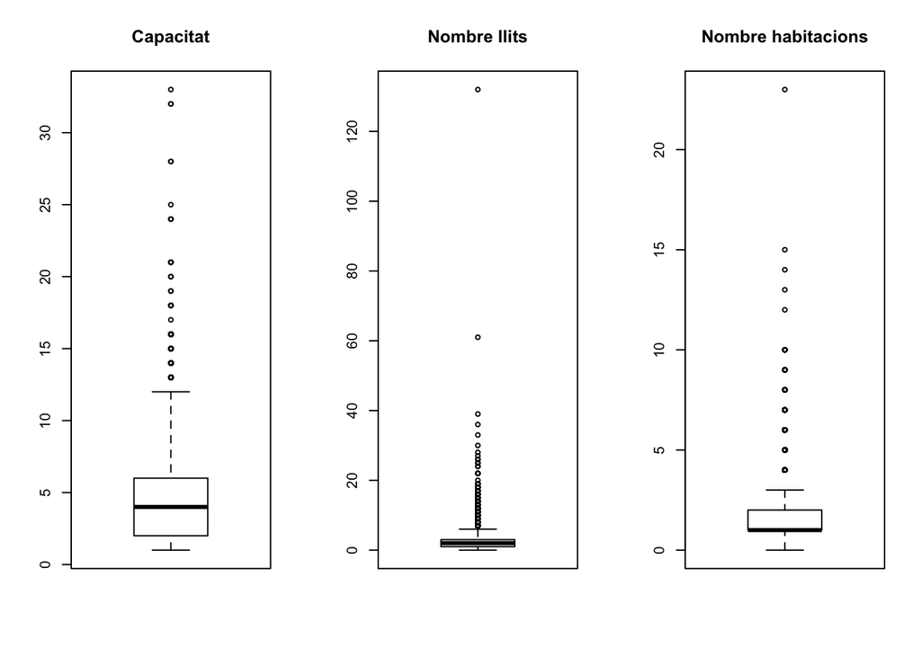

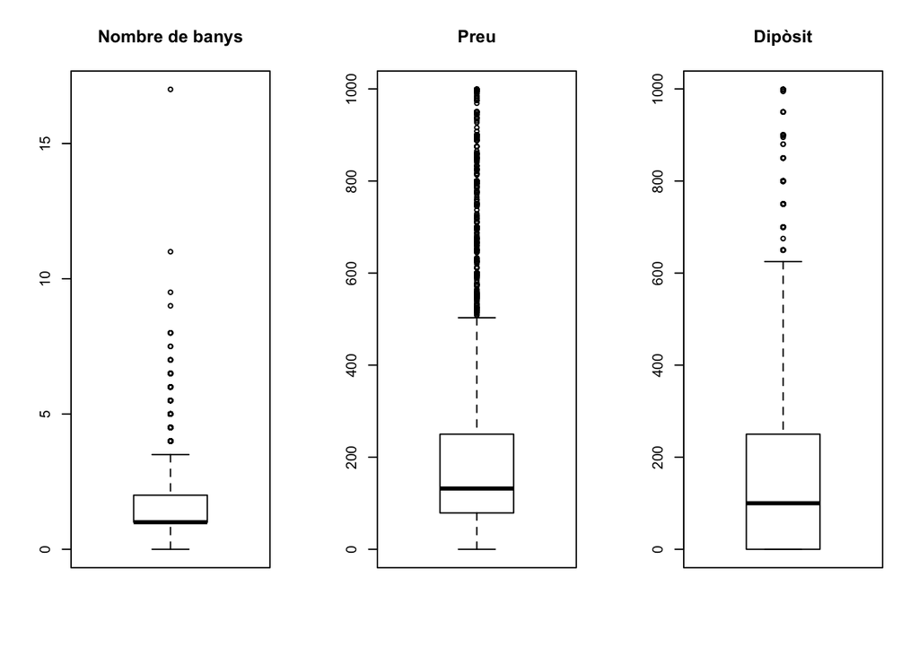

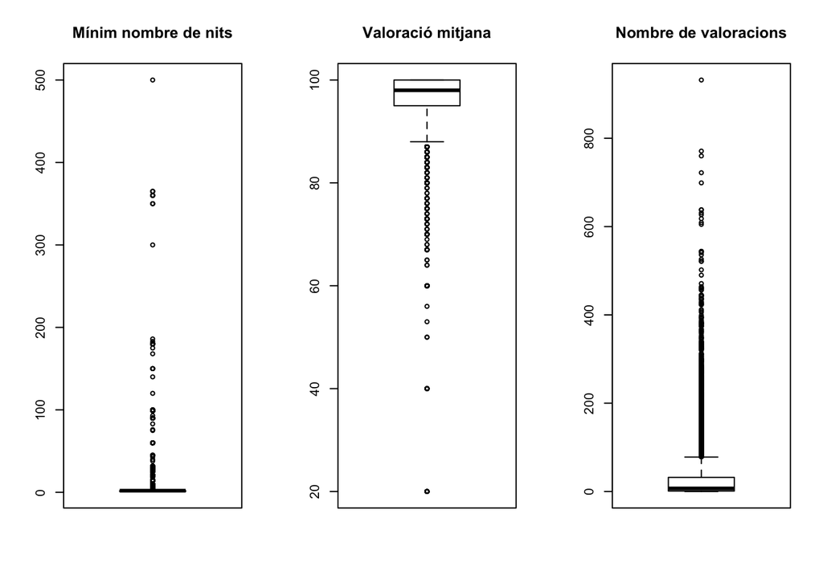

```r
#Aquesta instrucció mostra tots els boxplots en el mateix gràfic, amb la mateixa escala i amb etiquetes
#en vertical
#boxplot(data[varnum], las=2)

#si volem mostrar cada boxplot en la seva escala:
par(mfrow=c(1,3)) #mostra 3 boxplots per fila

#si volem controlar el tamany de cada boxplot individual:
# https://www.datamentor.io/r-programming/subplot/

# versió 1
# for(i in 1:ncol(data)) {
#   if (names(data)[i] %in% varnum) {
#     boxplot(data[,i], main = names(data)[i])
#   }
# }
for(i in 1:ncol(datanum))
  boxplot(datanum[,i], main = names(datanum)[i])
```

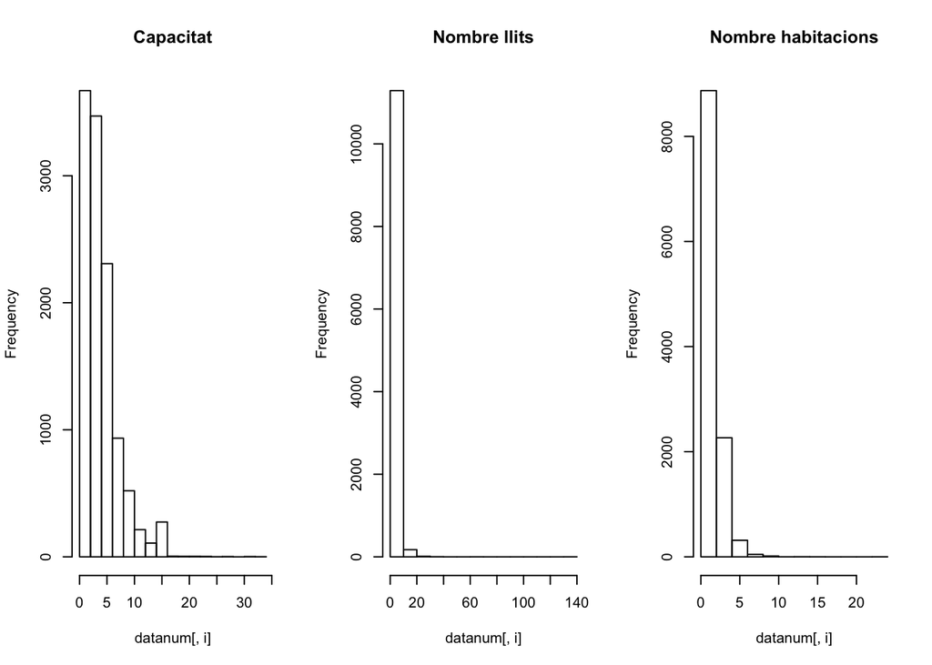

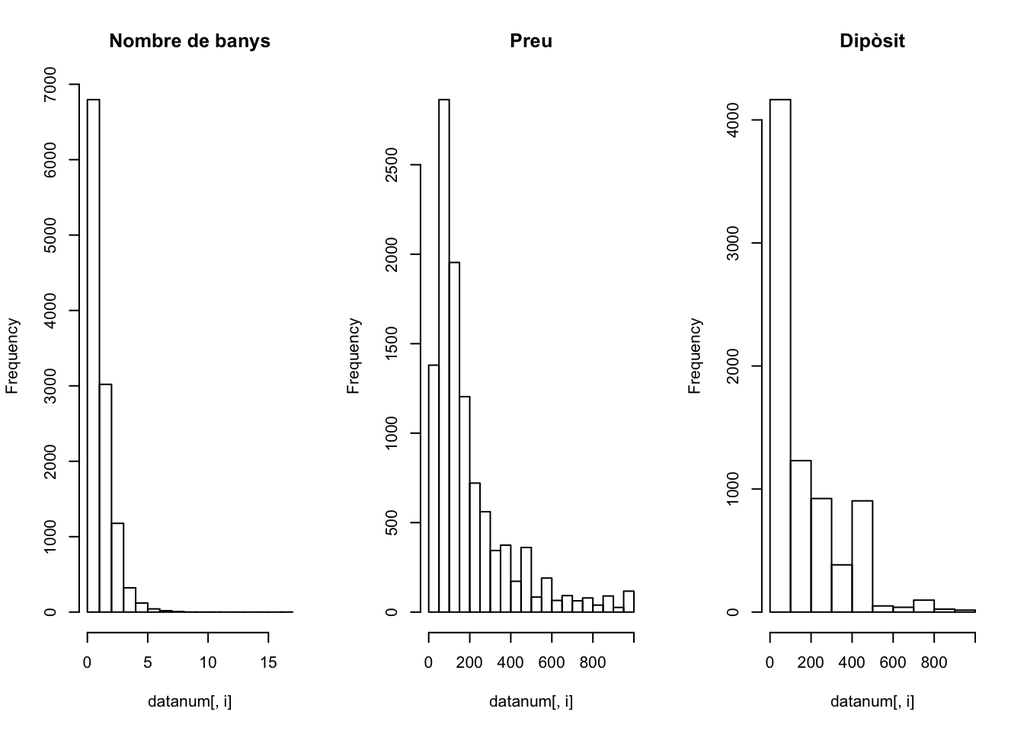

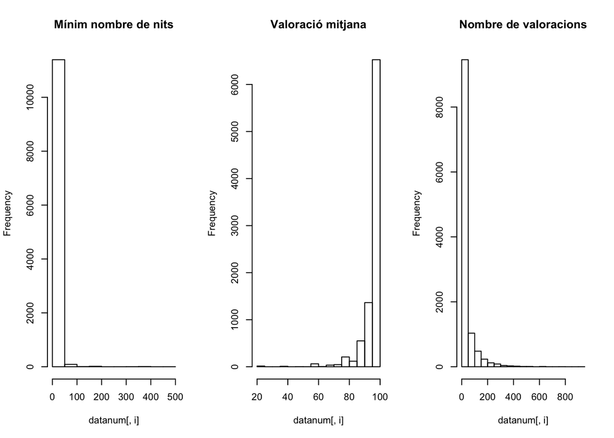

```r
#histogrames
par(mfrow=c(1,3)) #mostra 2 histogrames per fila
#versió 1
# for(i in 1:ncol(data)) {
#   if (names(data)[i] %in% varnum) {
#     hist(data[,i], main = names(data)[i])
#   }
# }
for(i in 1:ncol(datanum))
  hist(datanum[,i], main = names(datanum)[i])
```

Diagrama de tarta dels tipus de vivendes, agrupant com a “Altres” els tipus que representin un percentatge inferior a l’1% del total

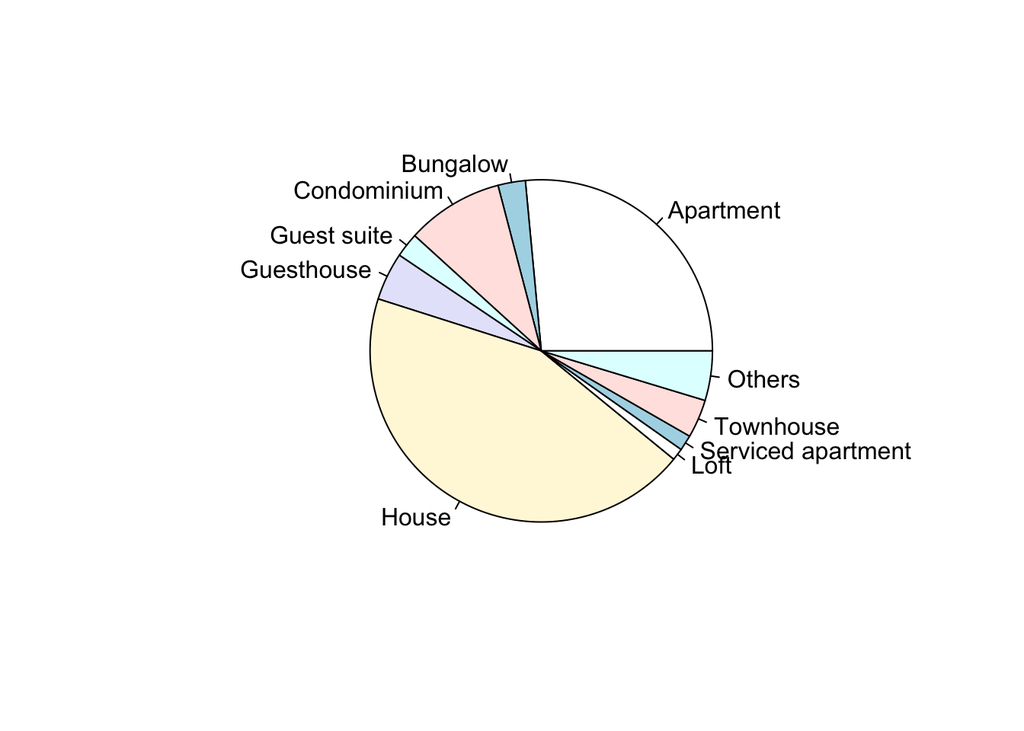

```r
#pie(table(data$Tipus), main = "Tipus de vivenda")

selected=table(data$Tipus)[100*prop.table(table(data$Tipus)) > 1]
numothers=sum(table(data$Tipus))-sum(selected)
dtaux=rbind(data.frame(selected), data.frame(Var1="Others", Freq=numothers))
pie(dtaux$Freq, labels=dtaux$Var1)
```

Preu mitjà segons el barri, de menor a major i sense tenir en compte noms de Barri incorrectes (“” o “N/A”).

```r
#aggregate(Preu~Barri, data=data, FUN=mean, na.rm=TRUE)

#create data frame containing only valid rows (with Barri != N/A or empty string)
datavalid=data[data$Barri != "" & data$Barri != "N/A", ]

#compute average Preu, for each Barri
result=aggregate(Preu~Barri, data=datavalid, FUN=mean, na.rm=TRUE)
#sort the results in increasing value
result[order(result$Preu), ]
```

```
##                         Barri      Preu
## 2               Anderson Mill  83.00000
## 54             Scofield Ridge  89.05000
## 63          SW Williamson Co.  94.38961
## 17                Copperfield  98.01667
## 26             Georgian Acres  99.00000
## 37                    Milwood 105.43182
## 33          Lamplight Village 107.35556
## 28                 Gracywoods 108.48750
## 77                     Wooten 109.15000
## 35                   McKinney 112.00483
## 41                 North Loop 112.71809
## 42          North Shoal Creek 113.90909
## 60                  St. Johns 118.52632
## 3                Angus Valley 119.60000
```

[output cut: 64 more lines]

Preu mitjà segons la capacitat de la vivenda, de menor a major.

```r
result=aggregate(Preu~Capacitat, data=data, FUN=mean, na.rm=TRUE)
result[order(result$Preu), ]
```

```
##    Capacitat      Preu
## 1          1  71.40956
## 2          2 108.46371
## 3          3 135.41703
## 4          4 206.26818
## 5          5 222.32468
## 6          6 280.15150
## 7          7 309.03376
## 8          8 343.02658
## 9          9 384.00000
## 11        11 395.82353
## 10        10 427.67989
## 12        12 428.28873
## 13        13 434.80000
## 14        14 451.58730
## 16        16 473.67358
## 15        15 542.00000
## 18        21 555.00000
## 20        25 633.00000
## 19        24 812.50000
## 17        18 927.00000
```

Boxplot de la variable ‘Preu’, per als 5 barris més cars (preu mitjà més alt) i els 5 barris més barats (preu mitjà més baix), en un mateix diagrama. Els boxplots han d’indicar també el valor mitjà de les dades.

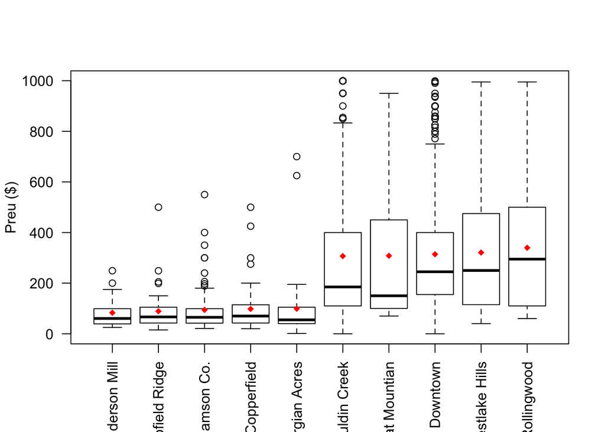

```r
#boxplot(Preu~Barri, data=data, ylab="Preu ($)", las=2)

#create data frame containing only valid rows (with Barri != N/A or empty string)
datavalid=data[data$Barri != "" & data$Barri != "N/A", ]

#compute average Preu, for each Barri
result=aggregate(Preu~Barri, data=datavalid, FUN=mean, na.rm=TRUE)
#sort the results in increasing value
sorted=result[order(result$Preu), ]

#create new data frame containing only the selected rows (Barris in top 5 or bottom 5, sorted by average Preu)
dtaux=data[data$Barri == sorted[1,1], ]
for(i in 2:5)
  dtaux=rbind(dtaux, data[data$Barri == sorted[i,1], ])

nvalues=nrow(sorted)
for(i in (nvalues-4):nvalues)
  dtaux=rbind(dtaux, data[data$Barri == sorted[i,1], ])

#remove unused levels
dtaux=droplevels(dtaux)

medias=aggregate(Preu~Barri, data=dtaux, FUN=mean)

#reorder factor levels depending on average of Preu
dtaux2=dtaux
dtaux2$Barri=factor(dtaux2$Barri, levels=medias[order(medias$Preu),]$Barri)

#boxplot(Preu~Barri, data=dtaux, ylab="Preu ($)", las=2)
#points(medias, col="red", pch=18)

medias2=aggregate(Preu~Barri, data=dtaux2, FUN=mean)
boxplot(Preu~Barri, data=dtaux2, ylab="Preu ($)", las=2)
points(medias2, col="red", pch=18)
```

Diagrames de dispersió dos a dos de les variables “Capacitat”, “Nombre de banys”, “Preu” i “Valoració mitjana”, amb colors diferents per a cada barri.

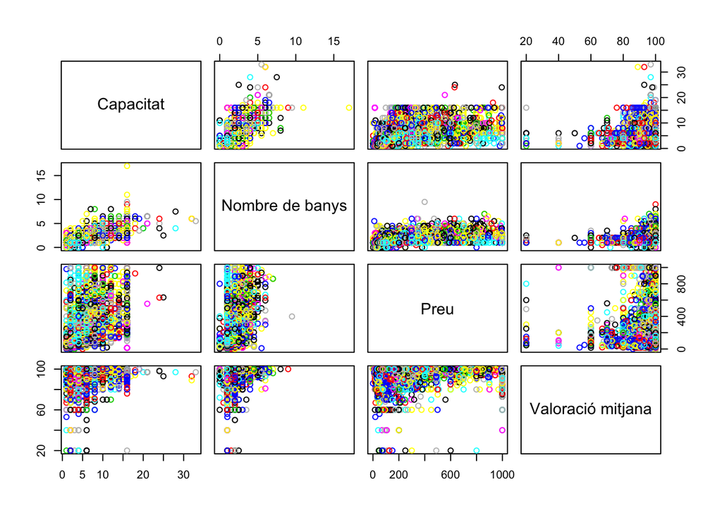

```r
# variables numèriques
varsel=c("Barri", "Capacitat", "Nombre de banys", "Preu", "Valoració mitjana")

# data frame només amb variables numèriques
datasel=data[varsel]

plot(datasel[, 2:5], col=as.numeric(datasel$Barri))
```

Coeficients de correlació dos a dos de les variables “Capacitat”, “Nombre de banys”, “Preu” i “Valoració mitjana”, sense tenir en compte els valors NA. Comentau els resultats.

```r
# variables numèriques
varsel=c("Capacitat", "Nombre de banys", "Preu", "Valoració mitjana")

# data frame només amb variables numèriques
datasel=data[varsel]

cor(datasel,  use="pairwise.complete.obs")
```

```
##                       Capacitat Nombre de banys        Preu
## Capacitat          1.0000000000      0.70063293  0.50926096
## Nombre de banys    0.7006329346      1.00000000  0.48535390
## Preu               0.5092609637      0.48535390  1.00000000
## Valoració mitjana -0.0006021792      0.05458627 -0.01681122
##                   Valoració mitjana
## Capacitat             -0.0006021792
## Nombre de banys        0.0545862741
## Preu                  -0.0168112180
## Valoració mitjana      1.0000000000
```

Organitzau les variables “Preu” i “Valoració mitjana” en una taula de contingència per intervals, amb un màxim de 5 intervals per a cada variable. Dibuixau el diagrama de mosaic associat a la taula.

```r
#data frame without rows containing NaNs in Preu or Valoracio
noNAs=is.na(data$Preu)!=TRUE & is.na(data$`Valoració mitjana`)!=TRUE
datavalid=data[noNAs, ]

#table(datavalid$Preu, datavalid$`Valoració mitjana`)

n=nrow(datavalid)
data1=datavalid$Preu
data2=datavalid$`Valoració mitjana`

k1=3
# Triam intervals de la mateixa amplada
A1=diff(range(data1))/k1
# organitzam dades en intervals tancats per l'esquerra i oberts per la dreta,
# excepte el darrer que també és tancat per la dreta
binnedPreu=cut(data1, breaks=min(data1) + A1*(0:k1), right=FALSE, include.lowest=TRUE)

k2=3
# Triam intervals de la mateixa amplada
A2=diff(range(data2))/k2
# organitzam dades en intervals tancats per l'esquerra i oberts per la dreta,
# excepte el darrer que també és tancat per la dreta
binnedVal=cut(data2, breaks=min(data2) + A2*(0:k2), right=FALSE, include.lowest=TRUE)

table(binnedPreu, binnedVal)
```

```
##            binnedVal
## binnedPreu  [20,46.7) [46.7,73.3) [73.3,100]
##   [0,333)          19          91       7085
##   [333,666)         2           7        934
##   [666,999]         3           6        302
```

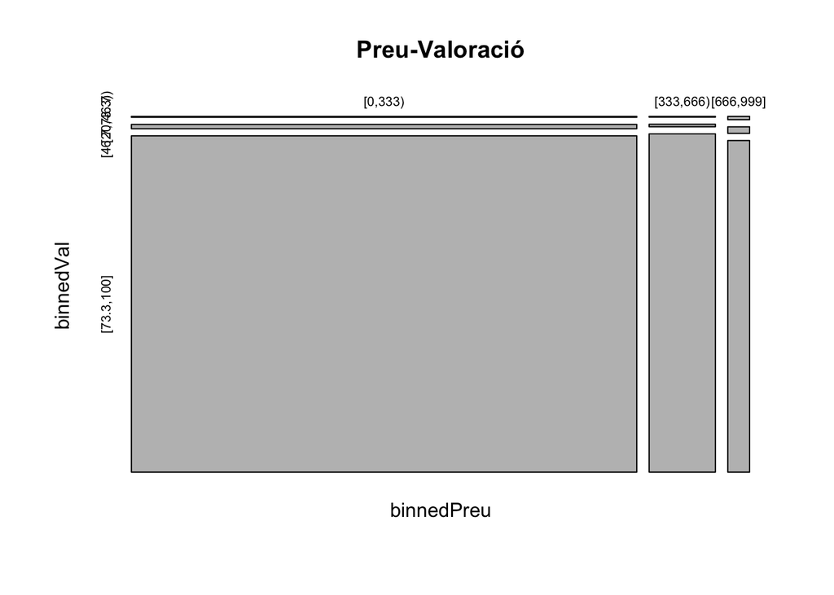

```r
plot(table(binnedPreu, binnedVal), main="Preu-Valoració")
```